# pi1 Enrichment Report

Darren Cameron

2025-11-18

## eQTL replication pipeline steps

1. `dwnld_obrien`: Download O’Brien 2018 bulk dev-brain eQTL files PMID:30419947
2. `dwnld_bryois`: Download Bryois 2022 sc-adult-brain eQTL files PMID:35915177
3. `dwnld_ziffra`: Download Ziffra 2021 snATAC-seq peaks files PMID:34616060
4. `dwnld_wen`: Download Wen 2024 bulk dev-brain eQTL files PMID:38781368
5. `snp_lookup`: Generate snp lookup for eQTL / ATAC-seq peak enrichments
6. `atac_enrich`: Test for eQTL enrichments in Ziffra ATAC-seq peaks
7. `cat_nom_qtl`: Combine per-chr nominal eQTL parquet files into gzip file for pi1 enrichment
8. `pi1_enrich_obrien`: Calc. pi1 enrichments between sn-eQTL and O’Brien 2018 bulk brain eQTL
9. `pi1_enrich_wen`: Calc. pi1 enrichments between sn-eQTL and Wen 2024 bulk brain eQTL
10. `pi1_enrich_bryois`: Calc. pi1 enrichments between sn-eQTL and Bryois 2022 adult brain sn-eQTL

Settings:

- Expression PC: 40 (see tensorQTL_report.html)
- Genotype PCs: 4 (see genotyping_post_impute_report.html)
- Norm methods: quantile

Test direction:

- Forward: Tests pi1 enrichment of our sig. sn-eQTL in public nominal eQTL data
- Reverse: Tests pi1 of public sig. sn-eQTL in our nominal sn-eQTL data

### Ziffra

#### Table

Table 1. sc-eQTL Enrichment in Ziffra et. al. (2021) snATAC-seq OCRs

Observed vs Permuted Overlap

| eQTL Cell Type | Peak Cell Type | P Value | Observed Overlap | Mean Permuted Overlap | Fold Enrichment |
| --- | --- | --- | --- | --- | --- |
| ExN-UL | dlEN | 0.001 | 254 | 72.2 | 3.520 |
| ExN-DL | dlEN | 0.001 | 255 | 73.5 | 3.470 |
| InN | IN_CGE | 0.001 | 124 | 38.8 | 3.190 |
| InN | IN_MGE | 0.001 | 124 | 37.2 | 3.330 |
| RG | RG | 0.001 | 245 | 70.1 | 3.490 |
| MG | Microglia | 0.001 | 7 | 1.1 | 6.240 |
| OPC | AstroOligo | 0.001 | 12 | 3.7 | 3.220 |
| Endo-Peri | EndoMural | 0.001 | 8 | 1.5 | 5.400 |

#### Heatmap

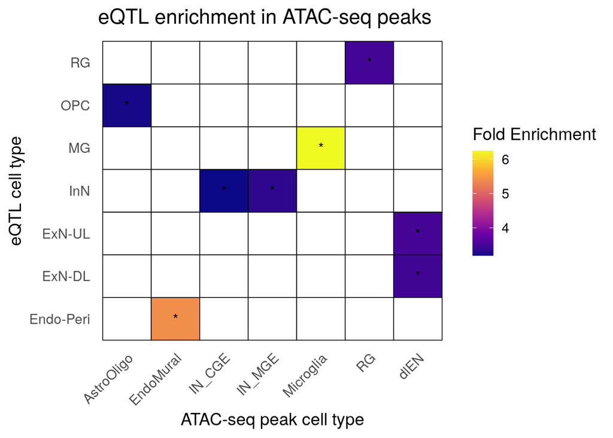

#### Bar plot

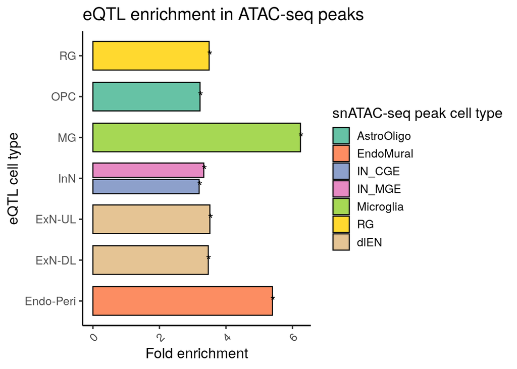

### O’Brien

#### Table

Table 2. Pi1 Enrichment: cell-specific eQTL with O'Brien et. al. (2018) bulk eQTL data

| Cell Type | ref_cell_type | Forward Test pi1 | Forward Test Prop. Replicating | Forward Test Prop. Same Dir. | Forward Test Overlap Count | Reference Test pi1 | Reference Test Prop. Replicating | Reference Test Prop. Same Dir. | Reference Test Overlap Count |
| --- | --- | --- | --- | --- | --- | --- | --- | --- | --- |
| ExN-UL | NA | 0.65 | 0.58 | 0.97 | 1401 | 0.90 | 0.93 | 0.95 | 543 |
| ExN-DL | NA | 0.69 | 0.58 | 0.97 | 1401 | 0.90 | 0.90 | 0.97 | 547 |
| InN | NA | 0.80 | 0.74 | 0.96 | 614 | 0.79 | 0.81 | 0.97 | 566 |
| RG | NA | 0.66 | 0.58 | 0.97 | 1279 | 0.79 | 0.84 | 0.98 | 556 |
| MG | NA | NA | NA | NA | 29 | 0.53 | 0.22 | 1.00 | 571 |
| OPC | NA | NA | NA | NA | 64 | 0.41 | 0.39 | 1.00 | 571 |
| Endo-Peri | NA | 0.30 | 0.75 | 0.97 | 52 | 0.59 | 0.35 | 0.99 | 571 |

#### Heatmap

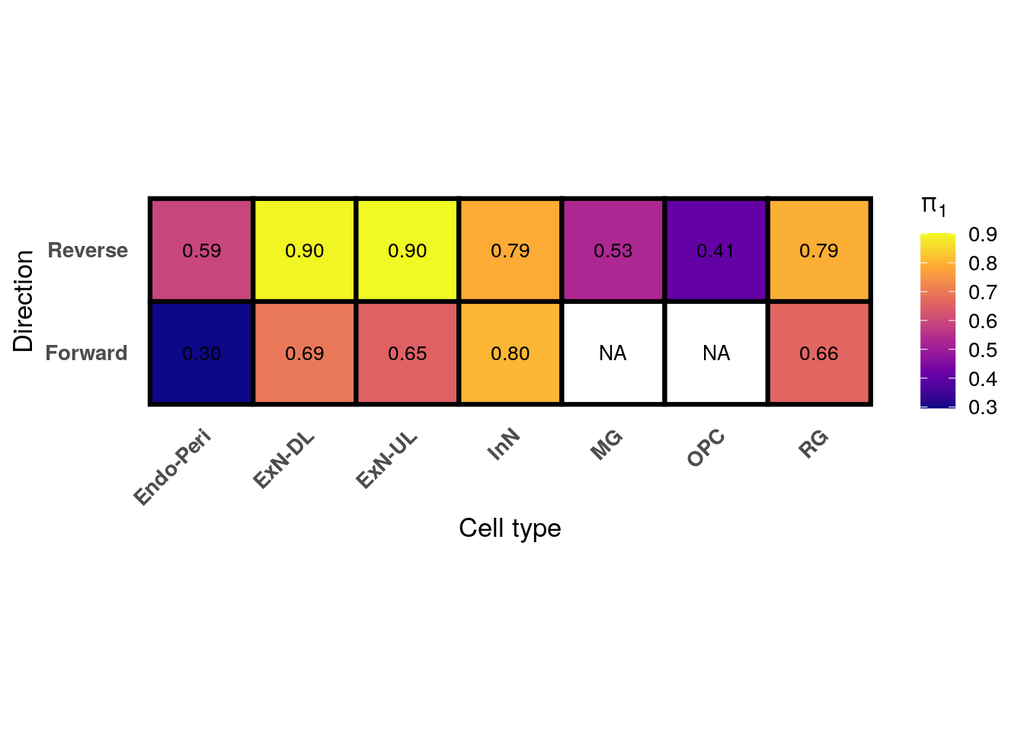

#### Forward histograms

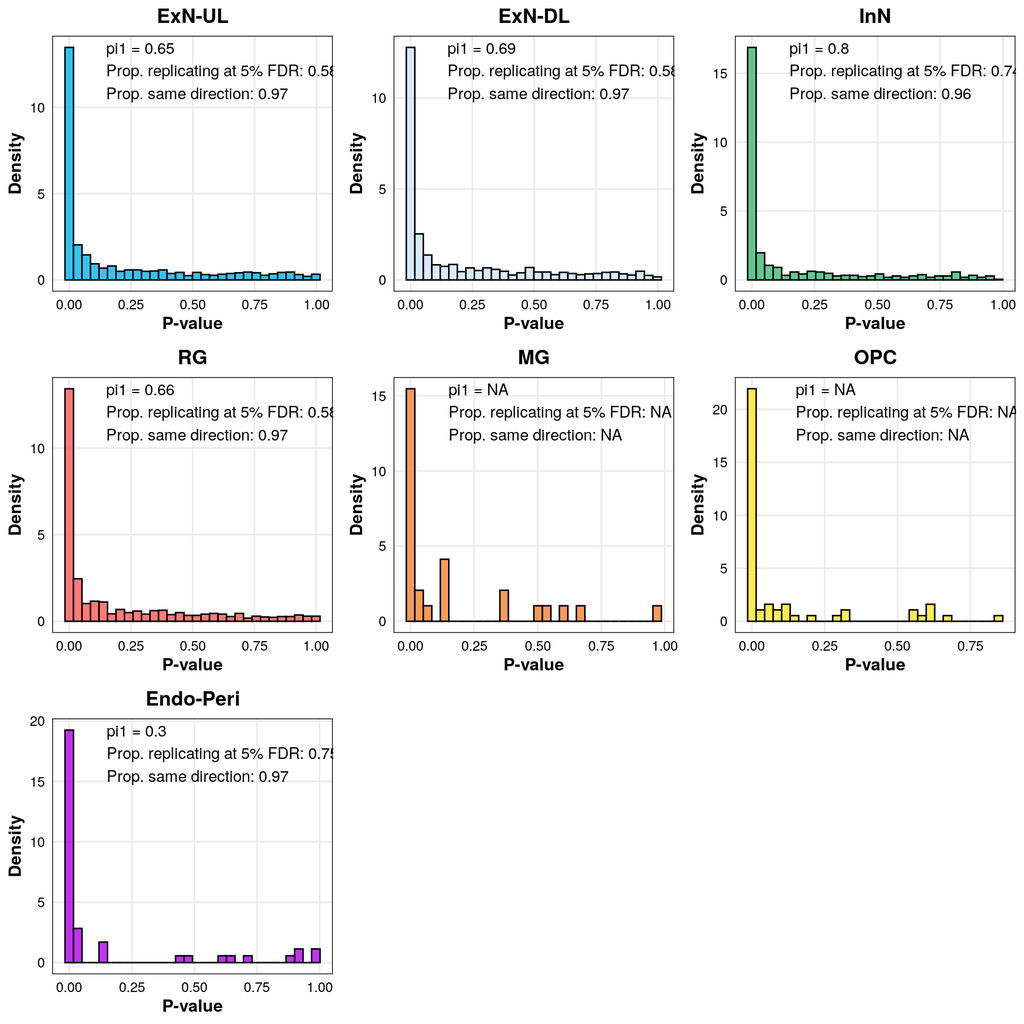

#### Reverse histograms

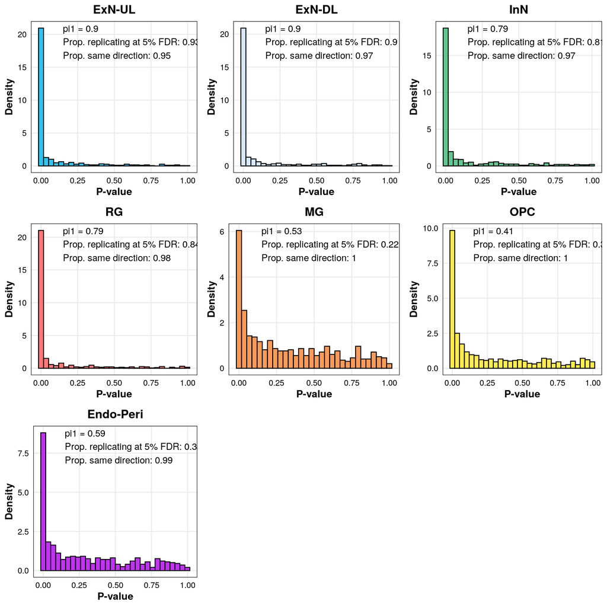

### Wen

#### Table

Table 3. Pi1 Enrichment: cell-specific eQTL with Wen et. al. (2024) bulk eQTL data

| Cell Type | ref_cell_type | Forward Test pi1 | Forward Test Prop. Replicating | Forward Test Prop. Same Dir. | Forward Test Overlap Count | Reference Test pi1 | Reference Test Prop. Replicating | Reference Test Prop. Same Dir. | Reference Test Overlap Count |
| --- | --- | --- | --- | --- | --- | --- | --- | --- | --- |
| ExN-UL | NA | 0.72 | 0.73 | 0.94 | 1097 | 0.69 | 0.62 | 0.93 | 1767 |
| ExN-DL | NA | 0.70 | 0.71 | 0.95 | 1113 | 0.72 | 0.62 | 0.93 | 1794 |
| InN | NA | 0.88 | 0.87 | 0.93 | 484 | 0.64 | 0.47 | 0.95 | 1856 |
| RG | NA | 0.76 | 0.75 | 0.95 | 965 | 0.68 | 0.61 | 0.92 | 1816 |
| MG | NA | NA | NA | NA | 20 | 0.20 | 0.05 | 0.95 | 1882 |
| OPC | NA | NA | NA | NA | 51 | 0.34 | 0.13 | 0.96 | 1882 |
| Endo-Peri | NA | NA | NA | NA | 40 | 0.31 | 0.09 | 0.96 | 1882 |

#### Heatmap

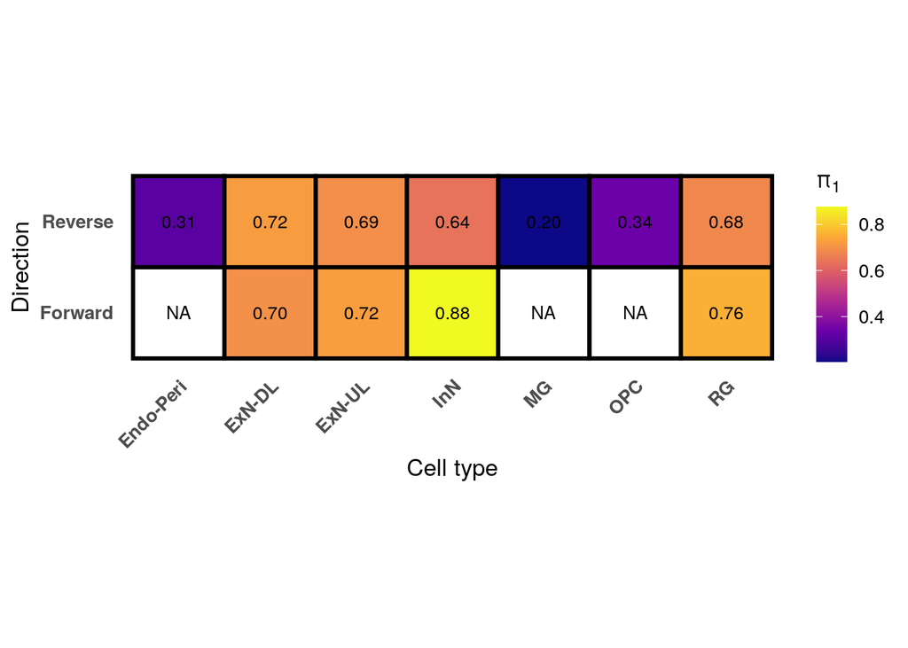

#### Forward histograms

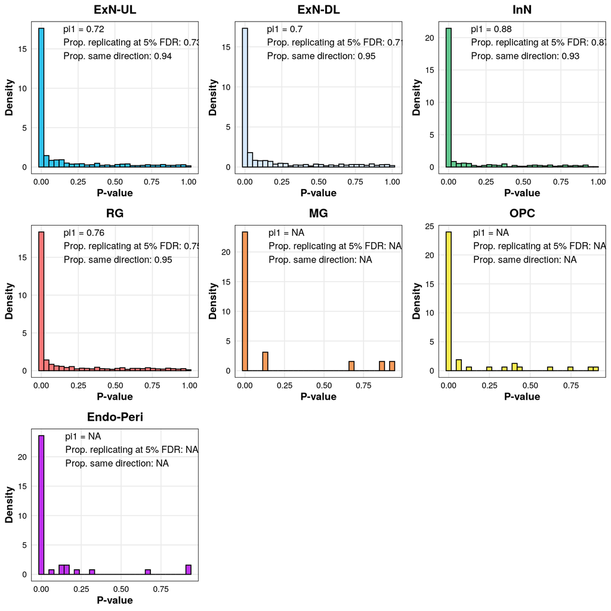

#### Reverse histograms

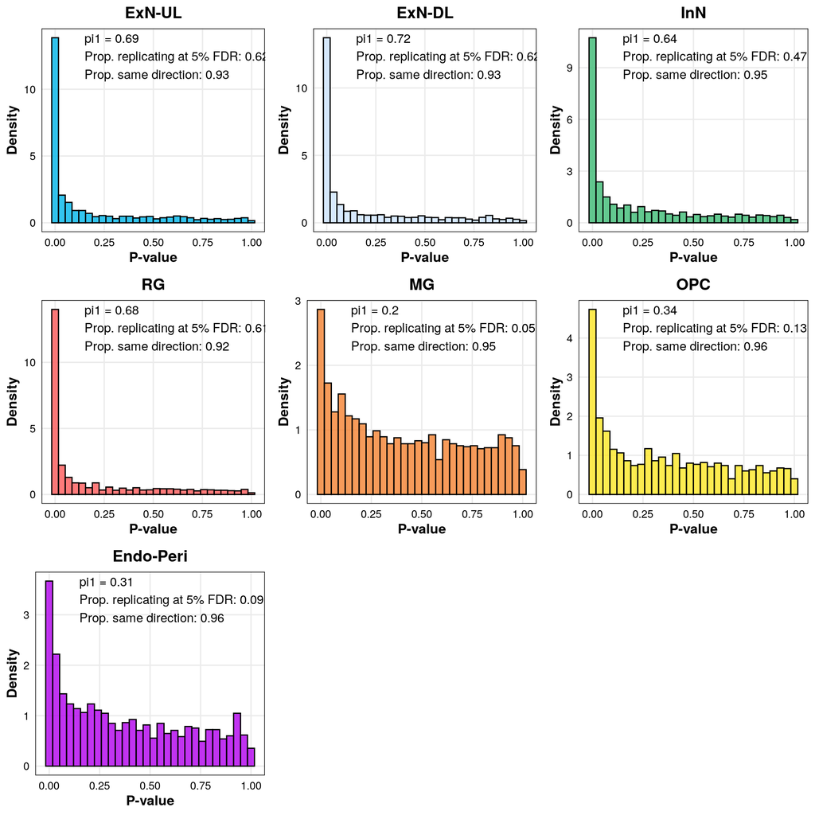

### Internal

#### Table

Table 4. internal Pi1 Enrichment Summary cell-specific eQTL

| Cell Type | Reference Cell Type | Forward Test pi1 | Forward Test Prop. Replicating | Forward Test Prop. Same Dir. | Forward Test Overlap Count | Reference Test pi1 | Reference Test Prop. Replicating | Reference Test Prop. Same Dir. | Reference Test Overlap Count |
| --- | --- | --- | --- | --- | --- | --- | --- | --- | --- |
| ExN-UL | ExN-UL | NA | NA | NA | NA | NA | NA | NA | NA |
| ExN-DL | ExN-UL | 0.96 | 1.00 | 0.98 | 2001 | 0.95 | 1.00 | 0.98 | 2009 |
| InN | ExN-UL | 0.97 | 1.00 | 0.98 | 931 | 0.92 | 0.96 | 0.98 | 2024 |
| RG | ExN-UL | 0.91 | 0.97 | 0.99 | 1806 | 0.94 | 0.99 | 0.99 | 2011 |
| MG | ExN-UL | NA | NA | NA | 48 | 0.58 | 0.26 | 1.00 | 2027 |
| OPC | ExN-UL | NA | NA | NA | 117 | 0.71 | 0.51 | 0.99 | 2027 |
| Endo-Peri | ExN-UL | 0.80 | 0.90 | 1.00 | 88 | 0.64 | 0.39 | 0.99 | 2027 |
| ExN-UL | ExN-DL | 0.95 | 1.00 | 0.98 | 2009 | 0.96 | 1.00 | 0.98 | 2001 |
| ExN-DL | ExN-DL | NA | NA | NA | NA | NA | NA | NA | NA |
| InN | ExN-DL | 0.96 | 1.00 | 0.98 | 939 | 0.92 | 0.96 | 0.98 | 2043 |
| RG | ExN-DL | 0.95 | 0.99 | 0.98 | 1817 | 0.95 | 1.00 | 0.98 | 2027 |
| MG | ExN-DL | NA | NA | NA | 48 | 0.53 | 0.24 | 0.99 | 2048 |
| OPC | ExN-DL | NA | NA | NA | 117 | 0.65 | 0.46 | 1.00 | 2048 |
| Endo-Peri | ExN-DL | 0.71 | 0.91 | 1.00 | 87 | 0.53 | 0.35 | 0.99 | 2048 |
| ExN-UL | InN | 0.92 | 0.96 | 0.98 | 2024 | 0.97 | 1.00 | 0.98 | 931 |
| ExN-DL | InN | 0.92 | 0.96 | 0.98 | 2043 | 0.96 | 1.00 | 0.98 | 939 |
| InN | InN | NA | NA | NA | NA | NA | NA | NA | NA |
| RG | InN | 0.89 | 0.94 | 0.99 | 1854 | 0.95 | 1.00 | 0.98 | 945 |
| MG | InN | NA | NA | NA | 50 | 0.69 | 0.53 | 0.99 | 952 |
| OPC | InN | NA | NA | NA | 117 | 0.88 | 0.84 | 0.98 | 952 |
| Endo-Peri | InN | 0.82 | 0.89 | 0.98 | 90 | 0.73 | 0.67 | 0.98 | 952 |
| ExN-UL | RG | 0.94 | 0.99 | 0.99 | 2011 | 0.91 | 0.97 | 0.99 | 1806 |
| ExN-DL | RG | 0.95 | 1.00 | 0.98 | 2027 | 0.95 | 0.99 | 0.98 | 1817 |
| InN | RG | 0.95 | 1.00 | 0.98 | 945 | 0.89 | 0.94 | 0.99 | 1854 |
| RG | RG | NA | NA | NA | NA | NA | NA | NA | NA |
| MG | RG | NA | NA | NA | 51 | 0.56 | 0.29 | 0.99 | 1860 |
| OPC | RG | 0.86 | 0.97 | 1.00 | 117 | 0.75 | 0.56 | 0.99 | 1860 |
| Endo-Peri | RG | NA | NA | NA | 89 | 0.59 | 0.44 | 1.00 | 1860 |
| ExN-UL | MG | 0.58 | 0.26 | 1.00 | 2027 | NA | NA | NA | 48 |
| ExN-DL | MG | 0.53 | 0.24 | 0.99 | 2048 | NA | NA | NA | 48 |
| InN | MG | 0.69 | 0.53 | 0.99 | 952 | NA | NA | NA | 50 |
| RG | MG | 0.56 | 0.29 | 0.99 | 1860 | NA | NA | NA | 51 |
| MG | MG | NA | NA | NA | NA | NA | NA | NA | NA |
| OPC | MG | 0.85 | 0.93 | 0.96 | 117 | NA | NA | NA | 51 |
| Endo-Peri | MG | NA | NA | NA | 90 | NA | NA | NA | 51 |
| ExN-UL | OPC | 0.71 | 0.51 | 0.99 | 2027 | NA | NA | NA | 117 |
| ExN-DL | OPC | 0.65 | 0.46 | 1.00 | 2048 | NA | NA | NA | 117 |
| InN | OPC | 0.88 | 0.84 | 0.98 | 952 | NA | NA | NA | 117 |
| RG | OPC | 0.75 | 0.56 | 0.99 | 1860 | 0.86 | 0.97 | 1.00 | 117 |
| MG | OPC | NA | NA | NA | 51 | 0.85 | 0.93 | 0.96 | 117 |
| OPC | OPC | NA | NA | NA | NA | NA | NA | NA | NA |
| Endo-Peri | OPC | 0.74 | 0.80 | 1.00 | 90 | NA | NA | NA | 117 |
| ExN-UL | Endo-Peri | 0.64 | 0.39 | 0.99 | 2027 | 0.80 | 0.90 | 1.00 | 88 |
| ExN-DL | Endo-Peri | 0.53 | 0.35 | 0.99 | 2048 | 0.71 | 0.91 | 1.00 | 87 |
| InN | Endo-Peri | 0.73 | 0.67 | 0.98 | 952 | 0.82 | 0.89 | 0.98 | 90 |
| RG | Endo-Peri | 0.59 | 0.44 | 1.00 | 1860 | NA | NA | NA | 89 |
| MG | Endo-Peri | NA | NA | NA | 51 | NA | NA | NA | 90 |
| OPC | Endo-Peri | NA | NA | NA | 117 | 0.74 | 0.80 | 1.00 | 90 |
| Endo-Peri | Endo-Peri | NA | NA | NA | NA | NA | NA | NA | NA |

#### Heatmap

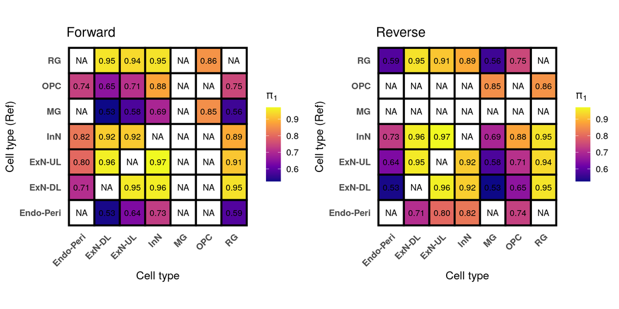

### Benchmarking

#### Table

Table 5. Benchmarking

Means and SD across replicates

| Rule | N | Mean Runtime (min) | SD Runtime (min) | Mean RAM (GB) | SD RAM (GB) |
| --- | --- | --- | --- | --- | --- |
| atac | 7 | 12.13 | 3.88 | 3.86 | 0.00 |
| cat | 7 | 9.73 | 0.40 | 5.37 | 0.28 |
| dwnld | 3 | 33.95 | 52.83 | 4.97 | 8.59 |
| pi1 | 169 | 3.62 | 3.41 | 9.34 | 4.02 |
| snp | 7 | 0.30 | 0.06 | 0.49 | 0.03 |

#### Plot

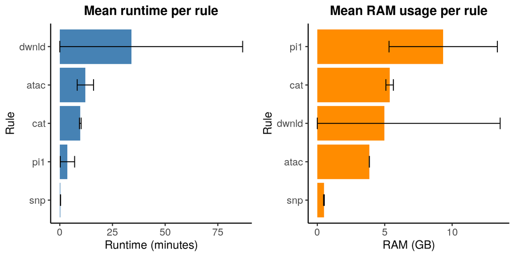